# build_honem(): embedding a higher-order network

honets

2026-08-26

## The analytic question

Network embeddings put nodes in a vector space so that structurally similar nodes end up near each other, making the network usable by anything that takes numeric features — clustering, regression, a downstream classifier.

Applied to a *first-order* network, an embedding can only encode who follows whom. HONEM (Saebi, Ciampaglia, Kaplan & Chawla 2020) embeds the **higher-order** network instead, so the vector for `Specify -> Command` reflects that context’s own continuation behaviour, not just `Command`’s.

The method builds higher-order neighbourhood matrices out to `max_power` steps, sums them into a single deviation matrix, and takes a truncated SVD.

```r
library(honets)
seqs <- split(human_long$code, human_long$session_id)
```

```r
library(cograph)
```

## Embedding

`build_honem()` consumes a fitted network, not raw sequences — build the higher-order network first and embed that.

```r
hon <- build_hon(seqs, max_order = 3, min_freq = 5)
em <- build_honem(hon, dim = 8)
em
```

```
HONEM: Higher-Order Network Embedding
  Nodes:      233
  Dimensions: 8
  Max power:  10
  Variance explained: 26.9%
```

233 nodes in 8 dimensions.

## Reading the coordinates

```r
as.data.frame(em, top = 6)
```

```
                             node       dim1         dim2         dim3
1                         Command 0.10835389 -0.154398248  0.051715108
2              Command -> Command 0.11456024 -0.193731474  0.070149078
3   Command -> Command -> Correct 0.02664611 -0.015416814  0.002878285
4 Command -> Command -> Frustrate 0.01972895 -0.006046598  0.003764183
5   Command -> Command -> Inquire 0.02891076 -0.062085853  0.023099962
6    Command -> Command -> Refine 0.14860198  0.022368050 -0.045598254
         dim4         dim5        dim6         dim7         dim8
1  0.02510722 -0.028266138  0.02764478 -0.031559640  0.009033542
2  0.00781994  0.003456093  0.01830600 -0.039714746  0.012523183
3 -0.01340167 -0.040384284 -0.02864752  0.007903811 -0.021335451
4 -0.01795680 -0.040783509 -0.17152152 -0.081260154  0.041315185
5 -0.09540003  0.128580191 -0.04820936  0.067604069 -0.012022753
6  0.14810405  0.035489749  0.05454319  0.010859133  0.019249940
```

One row per higher-order node. Note what the rows are: `Command` is a first-order node, `Command -> Command` a second-order context, and `Command -> Command -> Correct` a third-order one. **All three are embedded in the same space**, which is what makes the representation useful — a context and the state it ends in can be compared directly.

## How many dimensions do you need?

```r
as.data.frame(em, what = "variance")
```

```
  dim singular_value proportion
1   1       1.929934 0.24268255
2   2       1.566702 0.15992874
3   3       1.479560 0.14263267
4   4       1.212437 0.09577948
5   5       1.205881 0.09474638
6   6       1.178771 0.09053424
7   7       1.168708 0.08899499
8   8       1.140164 0.08470095
```

The first dimension carries 24.3% of the squared singular value, the second 16.0%, and the tail flattens quickly — dimensions 4 through 8 each hold 8-10%. There is no sharp elbow, which is honest information: this network has no small set of dominant structural axes, and an 8-dimensional embedding is retaining genuinely distributed structure rather than noise.

```r
em20 <- build_honem(hon, dim = 20)
as.data.frame(em20, what = "variance", top = 6)
```

```
  dim singular_value proportion
1   1       1.929934 0.13227595
2   2       1.566702 0.08717036
3   3       1.479560 0.07774301
4   4       1.212437 0.05220533
5   5       1.205881 0.05164223
6   6       1.178771 0.04934637
```

```r
cumulative <- cumsum(as.data.frame(em20, what = "variance")$proportion)
data.frame(dims = c(2, 5, 10, 20), cumulative = round(cumulative[c(2, 5, 10, 20)], 3))
```

```
  dims cumulative
1    2      0.219
2    5      0.401
3   10      0.632
4   20      1.000
```

**`proportion` is relative to the dimensions retained, not to the full spectrum** — it sums to 1 by construction, so the same axis has a different share depending on `dim`. At `dim = 20` the first two axes hold 21.9% and the first ten 63.2%; the 24.3% reported for `dim1` above is its share of an 8-dimensional retention.

Compare like with like when choosing `dim`, and report the value you used.

## `max_power` sets how far the neighbourhood reaches

```r
do.call(rbind, lapply(c(2, 5, 10), function(mp) {
  e <- build_honem(hon, dim = 4, max_power = mp)
  v <- as.data.frame(e, what = "variance")
  data.frame(max_power = mp, dim1_share = round(v$proportion[1], 3),
             top4_share = round(sum(v$proportion), 3))
}))
```

```
  max_power dim1_share top4_share
1         2      0.365          1
2         5      0.378          1
3        10      0.379          1
```

Larger `max_power` accumulates longer-range neighbourhoods. Because every retained dimension’s share is computed within the retained set, these numbers describe how concentrated the structure is at each reach, not how much total variance is captured.

## Plotting

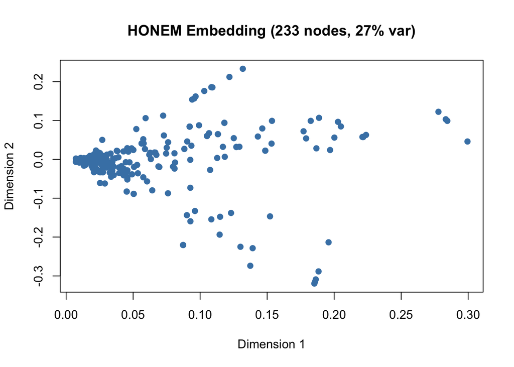

```r
plot(em, dims = c(1, 2))
```

Read this cautiously. A 2-D projection of an 8-D embedding shows the first two axes only — and per the variance table, that is 40% of the structure. Proximity in the plot is suggestive, not conclusive.

## The states the embedding sits over

The embedding has one row per higher-order *node* — 233 of them. That is far too many to draw: `splot(hon)` is an unreadable hairball, and it is the wrong picture anyway, because what the coordinates are relative to is the nine underlying states. Draw those.

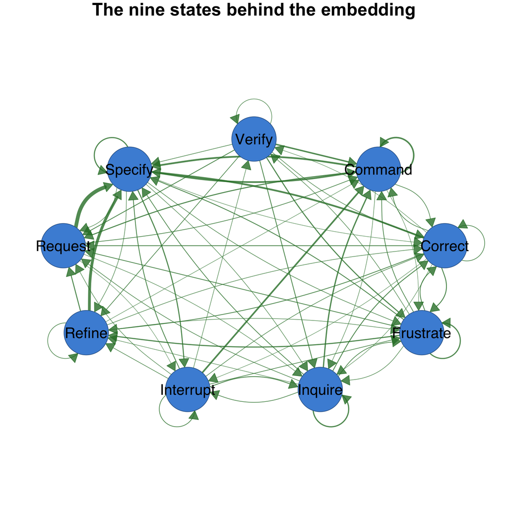

```r
net1 <- build_hon(human_long, action = "code", actor = "session_id",
                  time = "timestamp", max_order = 1, min_freq = 5)
splot(net1, minimum = 0.05, title = "The nine states behind the embedding")
```

Every point in the scatter above is a *context over these nine states* — `Command`, `Command -> Command`, `Command -> Command -> Correct` are three separate rows of the embedding and three separate paths through this graph.

## What an embedding is not

An embedding is a *representation*, not a result. Nothing above is a statistical claim: there are no p-values, no intervals, and the coordinates are only identified up to sign and rotation. Two runs on the same input agree exactly, but a change in `dim` or `max_power` produces a different space, not a rescaled one.

Use it as input to something that does make claims — and if the question is “which actions matter”, `hon_centrality()` answers it directly and interpretably instead.

## What to do next

- **`build_hon()`** — the network this verb consumes. The embedding inherits every choice made there, `min_freq` especially.
- **`hon_centrality()`** — an interpretable ranking rather than a latent space.
- **`hypergraph_cluster()`** — if the goal is grouping rather than coordinates.

## References

- Saebi, M., Ciampaglia, G. L., Kaplan, L. M., & Chawla, N. V. (2020). HONEM: Learning embedding for higher order networks. *Big Data*, 8(4), 255-269.
- Xu, J., Wickramarathne, T. L., & Chawla, N. V. (2016). Representing higher-order dependencies in networks. *Science Advances*, 2(5), e1600028.